# Ejercicio Guiado N°6 - Análisis de Datos y Estadística Computacional

- Mostrar todo el código
- Ocultar todo el código
- Ver el código fuente

Regresión Lineal Simple con `lm()`

Autor/a

Afiliación

Prof. Gabriel Duarte Zúñiga

Universidad Adolfo Ibáñez | DIAPP-2026

Fecha de publicación

4 de julio de 2026

**Antes de comenzar**

**Código**

```r
install.packages("tidyverse")
install.packages("broom")
install.packages("moderndive")
install.packages("wooldridge")
```

**Código**

```r
library(tidyverse)
library(broom)
library(moderndive)
library(wooldridge)

data(hprice1)
```

# Ejercicio Guiado

El dataset **`hprice1`** (Wooldridge) contiene información de **88 viviendas** vendidas en una zona de EE.UU. Nos interesa una pregunta simple: **¿cuánto se asocia el tamaño de una casa con su precio de venta?**

Trabajaremos con estas variables:

| Variable | Descripción |
| --- | --- |
| `price` | Precio de venta (en **miles** de USD) |
| `sqrft` | Superficie construida (en **pies cuadrados**) |
| `bdrms` | Número de dormitorios |
| `lotsize` | Tamaño del terreno (pies cuadrados) |
| `lprice` | Logaritmo natural de `price` |
| `lsqrft` | Logaritmo natural de `sqrft` |

> ⏱️ Objetivo: resolver la guía en **30 minutos**. Intente primero cada pregunta y luego despliegue la **Pauta** para revisar.

### Pregunta 1: Cargar y preparar los datos

Cargue el dataset `hprice1` y asígnelo a un objeto llamado `casas`. Luego seleccione solo las variables `price`, `sqrft`, `bdrms`, `lotsize`, `lprice` y `lsqrft`, sobrescribiendo el objeto `casas`. Use `glimpse()` para inspeccionar el resultado. ¿De qué tipo son las variables?

**Pauta**

**Código**

```r
casas <- hprice1 |>
  select(price, sqrft, bdrms, lotsize, lprice, lsqrft)

glimpse(casas)
```

```
Rows: 88
Columns: 6
$ price   <dbl> 300.000, 370.000, 191.000, 195.000, 373.000, 466.275, 332.500,…
$ sqrft   <int> 2438, 2076, 1374, 1448, 2514, 2754, 2067, 1731, 1767, 1890, 23…
$ bdrms   <int> 4, 3, 3, 3, 4, 5, 3, 3, 3, 3, 4, 5, 3, 3, 3, 4, 4, 3, 3, 4, 3,…
$ lotsize <dbl> 6126, 9903, 5200, 4600, 6095, 8566, 9000, 6210, 6000, 2892, 60…
$ lprice  <dbl> 5.703783, 5.913503, 5.252274, 5.273000, 5.921578, 6.144775, 5.…
$ lsqrft  <dbl> 7.798934, 7.638198, 7.225482, 7.277938, 7.829630, 7.920810, 7.…
```

### Pregunta 2: Explorar la relación

Obtenga estadísticas descriptivas de `casas` con `summary()`. Luego construya un gráfico de dispersión de `price` (eje Y) contra `sqrft` (eje X) y agregue la recta de regresión con `geom_smooth(method = "lm", se = FALSE)`. ¿Qué tipo de relación observa?

**Pauta**

**Código**

```r
summary(casas)
```

```
     price           sqrft          bdrms          lotsize          lprice
 Min.   :111.0   Min.   :1171   Min.   :2.000   Min.   : 1000   Min.   :4.710
 1st Qu.:230.0   1st Qu.:1660   1st Qu.:3.000   1st Qu.: 5733   1st Qu.:5.438
 Median :265.5   Median :1845   Median :3.000   Median : 6430   Median :5.582
 Mean   :293.5   Mean   :2014   Mean   :3.568   Mean   : 9020   Mean   :5.633
 3rd Qu.:326.2   3rd Qu.:2227   3rd Qu.:4.000   3rd Qu.: 8583   3rd Qu.:5.788
 Max.   :725.0   Max.   :3880   Max.   :7.000   Max.   :92681   Max.   :6.586
     lsqrft
 Min.   :7.066
 1st Qu.:7.415
 Median :7.520
 Mean   :7.573
 3rd Qu.:7.708
 Max.   :8.264
```

**Código**

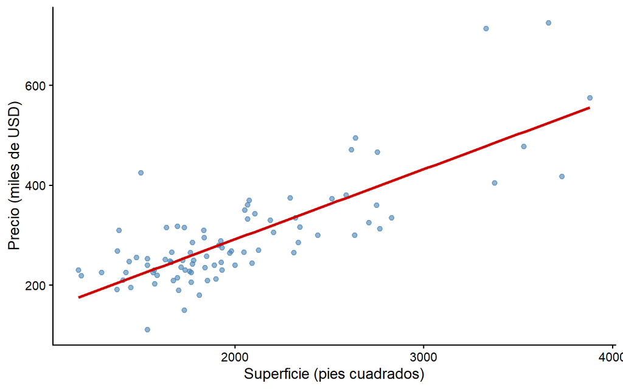

```r
ggplot(casas, aes(x = sqrft, y = price)) +
  geom_point(alpha = 0.6, color = "steelblue") +
  geom_smooth(method = "lm", se = FALSE, color = "red3") +
  labs(x = "Superficie (pies cuadrados)",
       y = "Precio (miles de USD)") +
  theme_classic(base_size = 14)
```

Se observa una relación **positiva y aproximadamente lineal**: las casas más grandes tienden a venderse a un precio mayor. Hay dispersión, pero la tendencia es clara. En las siguientes preguntas la vamos a **cuantificar**.

### Pregunta 3: Estimar la regresión simple

Estime un modelo de regresión lineal simple de `price` en función de `sqrft` y guárdelo en el objeto `reg1`. Muestre los resultados con `summary()`. **Interprete** el coeficiente de `sqrft` ($\hat{\beta}_1$) y el intercepto ($\hat{\beta}_0$).

**Pauta**

**Código**

```r
reg1 <- lm(price ~ sqrft, data = casas)
summary(reg1)
```

```
Call:
lm(formula = price ~ sqrft, data = casas)

Residuals:
     Min       1Q   Median       3Q      Max
-117.112  -36.348   -6.503   31.701  235.253

Coefficients:
            Estimate Std. Error t value Pr(>|t|)
(Intercept) 11.20415   24.74261   0.453    0.652
sqrft        0.14021    0.01182  11.866   <2e-16 ***
---
Signif. codes:  0 '***' 0.001 '**' 0.01 '*' 0.05 '.' 0.1 ' ' 1

Residual standard error: 63.62 on 86 degrees of freedom
Multiple R-squared:  0.6208,    Adjusted R-squared:  0.6164
F-statistic: 140.8 on 1 and 86 DF,  p-value: < 2.2e-16
```

Como no hay transformaciones, estamos ante una interpretación **nivel-nivel**:

- $\hat{\beta}_1 \approx 0{,}140$: por cada **pie cuadrado adicional**, el precio aumenta en promedio **0,140 miles de USD**, es decir, unos **$140**. (Equivale a ~$140.000 por cada 1.000 pies cuadrados adicionales.)
- $\hat{\beta}_0 \approx 11{,}20$: es el precio estimado cuando `sqrft = 0`. No tiene una interpretación práctica útil (ninguna casa mide 0 pies cuadrados); solo ancla la recta.

### Pregunta 4: Bondad de ajuste ($R^2$)

Extraiga el $R^2$ del modelo `reg1` usando `glance()`. Luego calcúlelo **manualmente** como el cociente entre la varianza de los valores ajustados y la varianza de `price`. ¿Coinciden? ¿Cómo lo interpreta?

**Pauta**

**Código**

```r
glance(reg1) |> select(r.squared, sigma, nobs)
```

| r.squared | sigma | nobs |
| --- | --- | --- |
| 0.6207967 | 63.61708 | 88 |

**Código**

```r
# Cálculo manual: var(y_gorro) / var(y)
var(fitted(reg1)) / var(casas$price)
```

```
[1] 0.6207967
```

Ambos métodos entregan el mismo valor: $R^2 \approx 0{,}621$. Esto significa que la superficie construida (`sqrft`) explica **cerca del 62%** de la variabilidad en los precios de venta. El resto se debe a otros factores no incluidos en el modelo (ubicación, terreno, antigüedad, etc.).

### Pregunta 5: Inferencia sobre el coeficiente

Use `get_regression_table()` (paquete `moderndive`) para obtener la tabla de resultados con intervalos de confianza. Plantee $H_0: \beta_1 = 0$ y $H_A: \beta_1 \neq 0$. A partir del **p-value** y del **intervalo de confianza al 95%**, ¿el efecto de `sqrft` es estadísticamente significativo al 5%?

**Pauta**

**Código**

```r
get_regression_table(reg1)
```

| term | estimate | std_error | statistic | p_value | lower_ci | upper_ci |
| --- | --- | --- | --- | --- | --- | --- |
| intercept | 11.204 | 24.743 | 0.453 | 0.652 | -37.983 | 60.391 |
| sqrft | 0.140 | 0.012 | 11.866 | 0.000 | 0.117 | 0.164 |

- El **p-value** de `sqrft` es prácticamente **0** (mucho menor que 0,05).
- El **IC al 95%** para $\hat{\beta}_1$ es aproximadamente **[0,117 ; 0,164]**, que **no contiene el cero**.

Ambos criterios llevan a la misma conclusión: **rechazamos** $H_0$. Existe evidencia estadística de que el tamaño de la casa se asocia con su precio.

### Pregunta 6: Cambiar la forma funcional (log-log)

Estime ahora un modelo con `lprice` como variable dependiente y `lsqrft` como variable explicativa; guárdelo en `reg2`. Muestre los resultados con `tidy()` (paquete `broom`). Como ambas variables están en logaritmo, ¿cómo cambia la **interpretación** de $\hat{\beta}_1$?

**Pauta**

**Código**

```r
reg2 <- lm(lprice ~ lsqrft, data = casas)
tidy(reg2)
```

| term | estimate | std.error | statistic | p.value |
| --- | --- | --- | --- | --- |
| (Intercept) | -0.9751299 | 0.64104848 | -1.521148 | 1.318910e-01 |
| lsqrft | 0.8726595 | 0.08460479 | 10.314541 | 1.051418e-16 |

Con la variable dependiente **y** la explicativa en logaritmo, estamos en un modelo **log-log**, donde $\hat{\beta}_1$ es una **elasticidad**:

$\hat{\beta}_1 \approx 0{,}87$ significa que un **aumento de 1% en la superficie** se asocia, en promedio, con un aumento de **≈ 0,87% en el precio**. A diferencia del modelo nivel-nivel de la Pregunta 3, aquí el efecto se lee en **términos porcentuales**.

# Resumen

| Paso | Función | ¿Qué hace? |
| --- | --- | --- |
| 1 | `lm(y ~ x, data)` | Estima la regresión por MCO |
| 2 | `summary()` | Resumen completo (coeficientes, $R^2$, significancia) |
| 3 | `broom::tidy()` | Coeficientes en formato tibble ordenado |
| 4 | `broom::glance()` | Métricas del modelo ($R^2$, sigma, n) |
| 5 | `moderndive::get_regression_table()` | Coeficientes + IC en una tabla |
| — | `geom_smooth(method = "lm")` | Dibuja la recta ajustada en `ggplot2` |

**Formas funcionales**

Recuerde la interpretación de $\hat{\beta}_1$ según el modelo: **nivel-nivel** → cambio en unidades; **log-nivel** → cambio en %; **log-log** → elasticidad (% sobre %).